# compare mesocosm treatments

Lisa Rosenthal

1/25/2019

I realized that I when I was running the simulations to t=20, I was halting one of the epipemics (add-deterministic, 1 species) before it plateued. This led to an increase in disease incidence, followed by a decrease for the add-deterministic treatment. If I run it to t=40, the “pathogen” stops spreading in all of the communities.

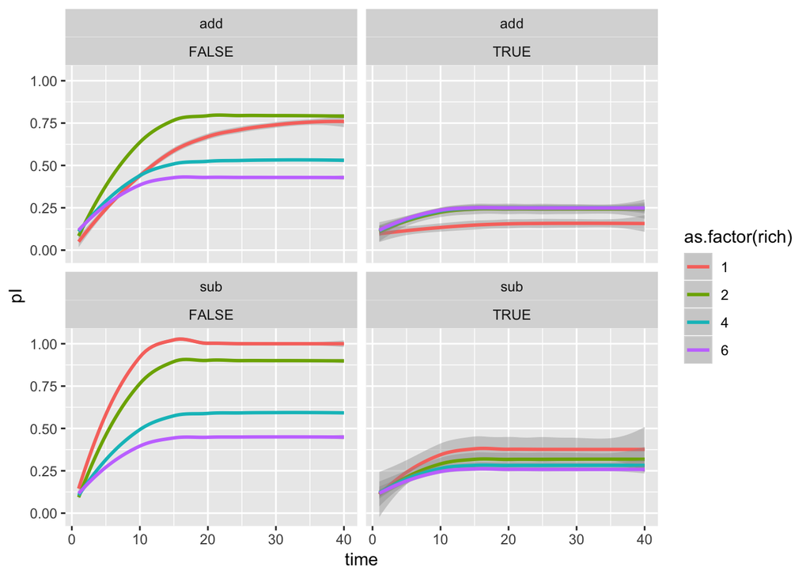

```r
#Note on treatment names: rand refers to assembly order, whether it's random (stochastic) or not (determistic). dens is the density treatment: additive or substitutive.
dat <- read.csv("simulation/outputs/moretime_responses.csv")
ggplot(filter(dat, species=="tot"), aes(time, pI))+
  geom_smooth(aes(group=rich,  color=as.factor(rich)))+
  facet_wrap(~dens+rand)
```

When I compare how the treatments change the relationship between incidence and disease, all of the curves are a little closer to being monotonic. While they aren’t technically linear, they are pretty close to it and maybe I can compare the slopes across treatments.

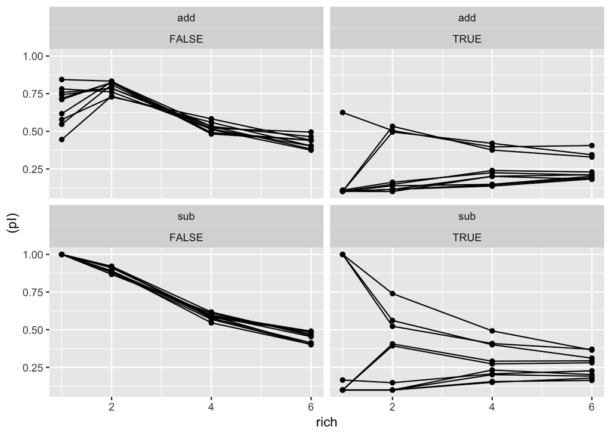

```r
#t=20
ggplot(filter(dat, species=="tot", time==20), aes(rich, (pI)))+
  geom_point()+
  geom_line(aes(group=interaction( rep)))+
  facet_wrap(~dens+rand)
```

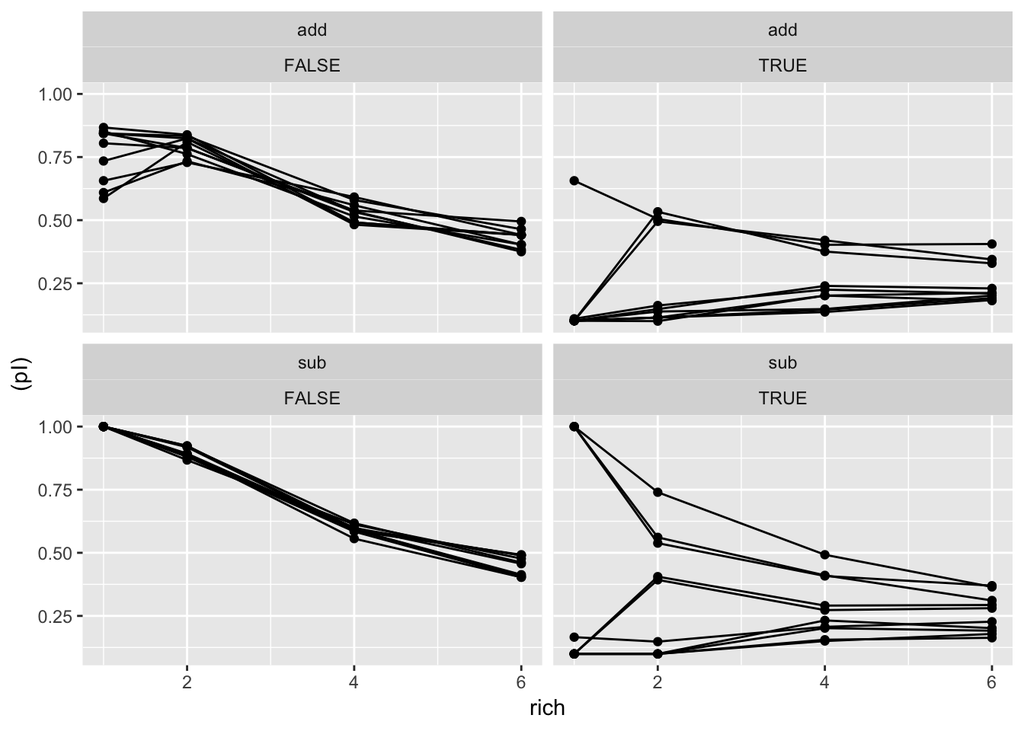

```r
#t=40
ggplot(filter(dat, species=="tot", time==40), aes(rich, (pI)))+
  geom_point()+
  geom_line(aes(group=interaction( rep)))+
  facet_wrap(~dens+rand)
```

Maybe the simplest way would be do do ANCOVA and compare the slopes between groups? I attempt to do it using the first model we talked about yesterday, but then I couldn’t figure out how to get compare slopes. So I tried it with m2 below.

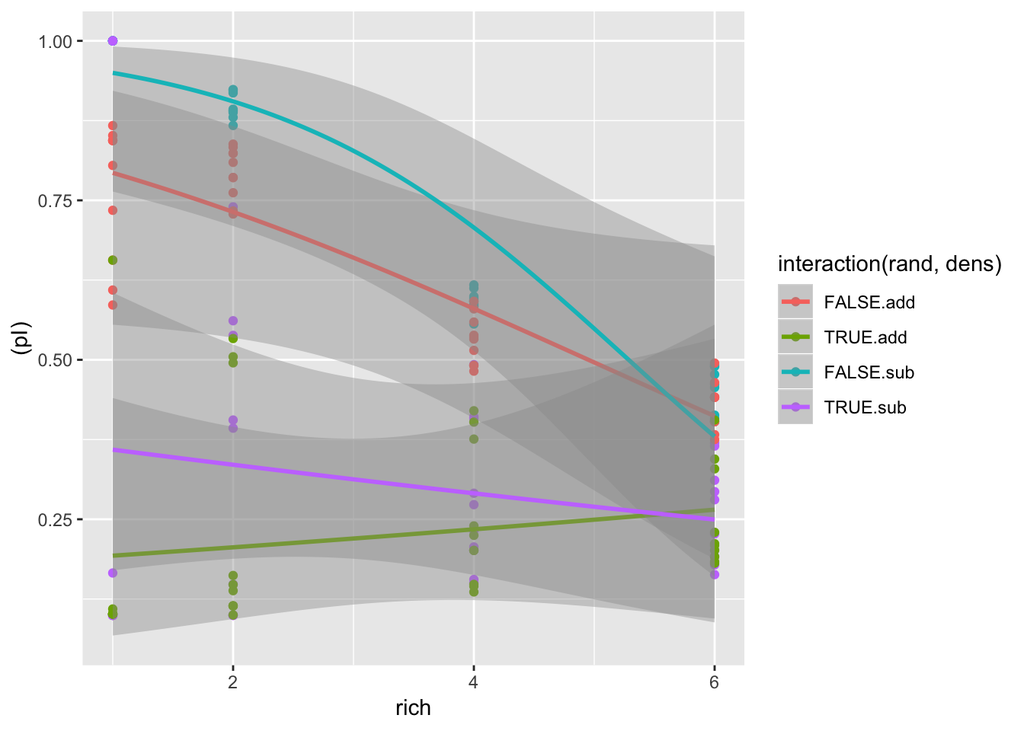

```r
dat40 <- dat %>%
  filter(time==40, species=="tot") %>%  #look at total infections at time final
  mutate(trt = interaction(dens, rand),
         rep2 = interaction(trt, rep), #rep ID in each trt group
         rep3 = case_when(rand==F~"det", T~as.character(rep2))) #assigning repID the same for all deterministic treatments since the species order is always the same.

#look at data
ggplot(dat40, aes(rich, (pI), color=interaction(rand, dens), group=interaction(rand, dens)))+
  geom_point()+
  geom_smooth(method='glm', method.args=list(family='binomial'))
```

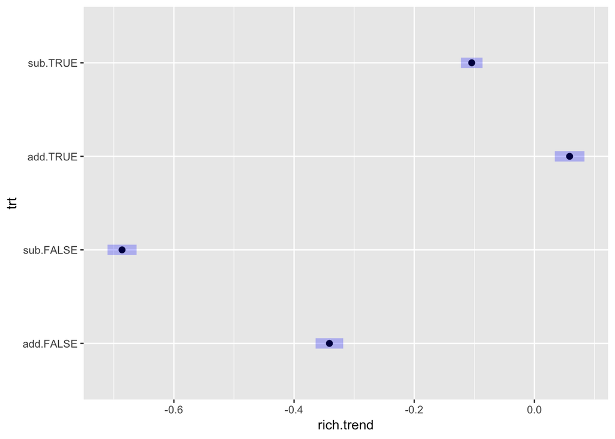

```r
#model from meeting. I care about the slopes. I use lstrends to pull that out with m2. if there's a way that's less black-boxy, I'm interested.
m1 <- glm(cbind(n.I, n.S) ~ dens*rand*rich, data = dat40, family = binomial)
#summary(m1)

m2 <- glm(cbind(n.I, n.S) ~ trt*rich, data = dat40, family = binomial)
#summary(m2)
lst <- emmeans::lstrends(m2, "trt", var="rich") #get estimates of how treatment covaries with richness
plot(lst) #the slopes of the lines. The SE are of the mean slope. Doesn't capture all of the variance in the data.
```

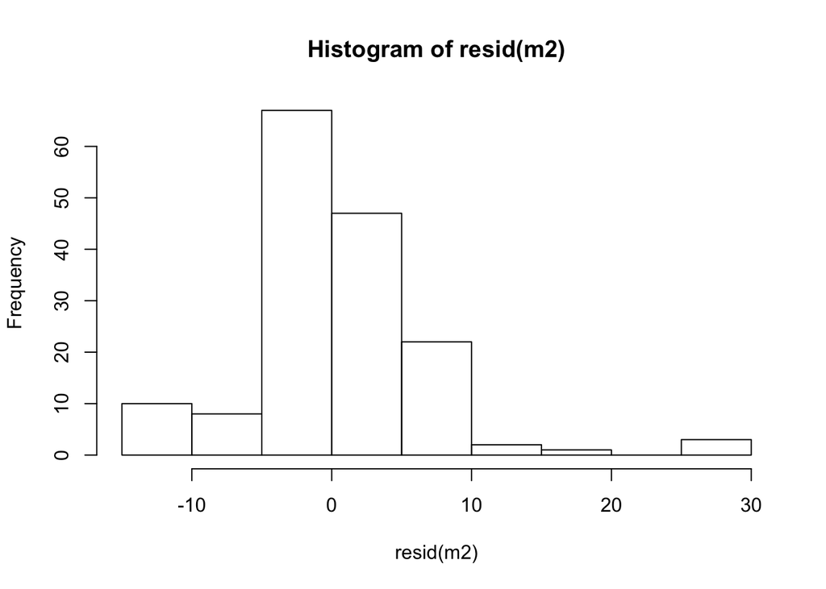

```r
#model evaluation
hist(resid(m2)) #not very normal!
```

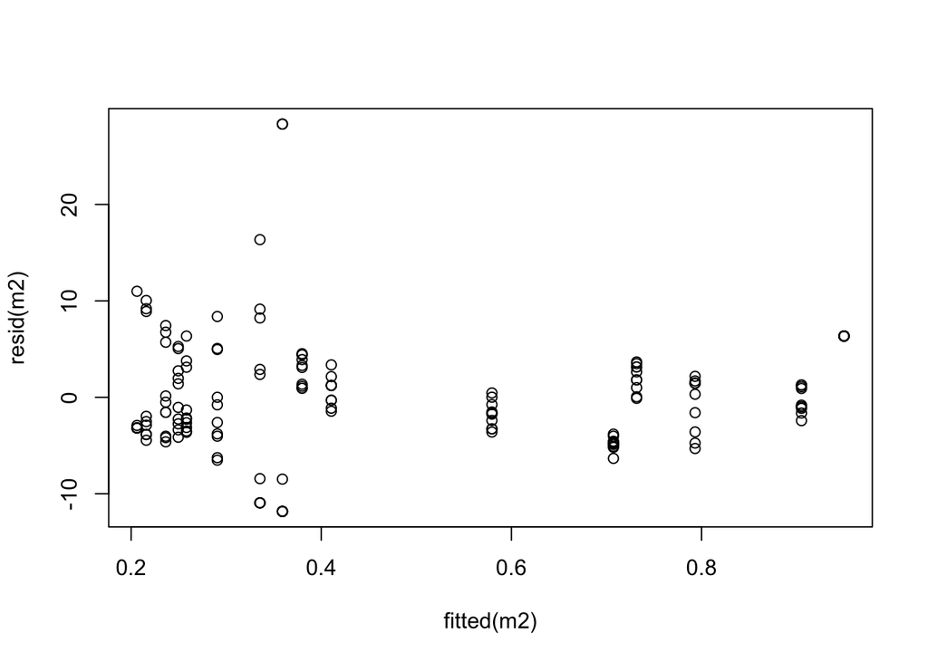

```r
#qqnorm(resid(m2))+qqline(resid(m2))
plot(resid(m2) ~ fitted(m2))#more variance at lower levels of infection
```

Does this approach work? The residuals aren’t normal and the variance is unequal, likely owing to the differences in variance beween the stochastic and deterministic treatments. Mainly I’m concerned that the SE of the slopes are not true to the data. I think I would want to put block (what I was calling rep) in there?

For example: `y ~ (trt+rep2)*rich` or `y ~ trt*rich + rep2`? There are issues with that too.

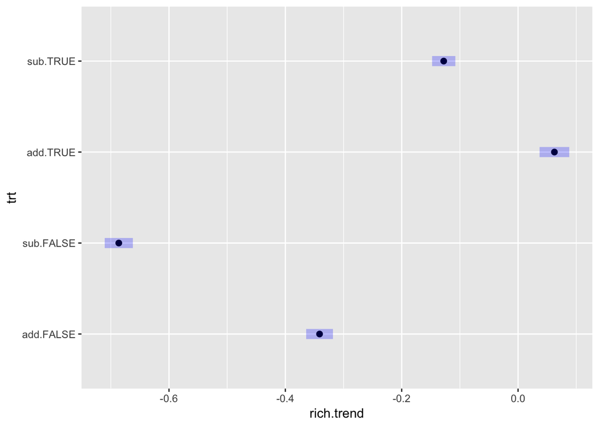

```r
#not all of the individuals are estimated. that ok?
m2.1 <- glm(cbind(n.I, n.S) ~ (trt+rep2)*rich, data = dat40, family = binomial) #slope varies with each block.
m2.2 <- glm(cbind(n.I, n.S) ~ trt*rich + rep2, data = dat40, family = binomial) #just intercept varies with each block.
m2.3 <- glm(cbind(n.I, n.S) ~ trt*rich + rep3, data = dat40, family = binomial) #rep3 assigns all of the deterministic blocks as the same.
m2.4 <- glm(cbind(n.I, n.S) ~ (trt+rep3)*rich, data = dat40, family = binomial)

#look at the model
model=m2.3
#summary(model) #lots of unestimated "reps". that ok?
emmeans::lstrends(model, "trt", var="rich") %>% plot #NOTE: A nesting structure was detected in the fitted model: rep2 %in% trt
```

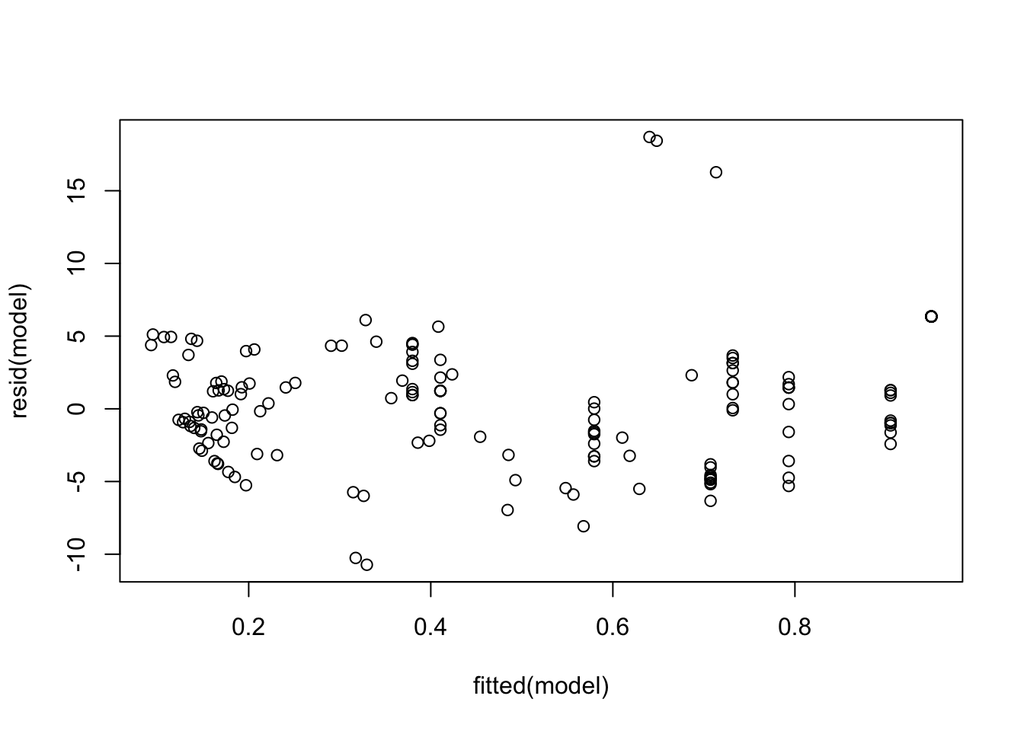

```r
#model eval. better
plot(resid(model) ~ fitted(model))
```

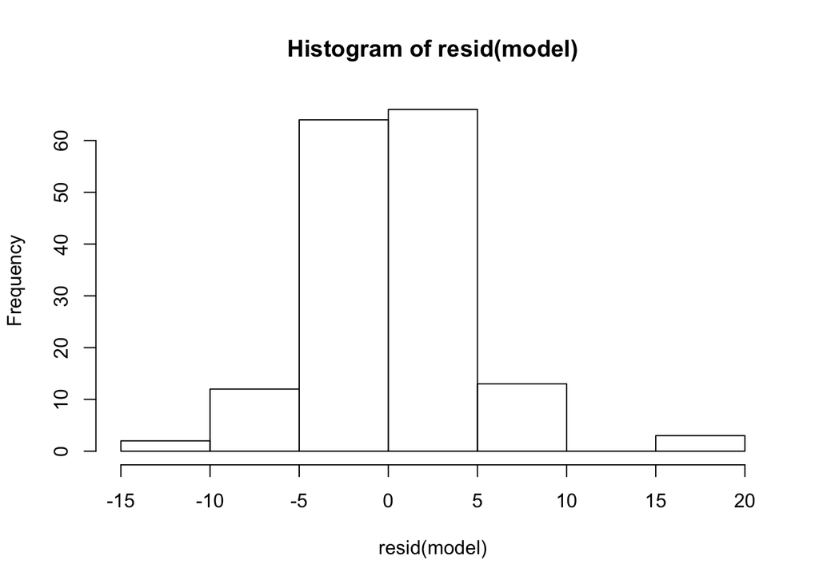

```r
hist(resid(model))
```

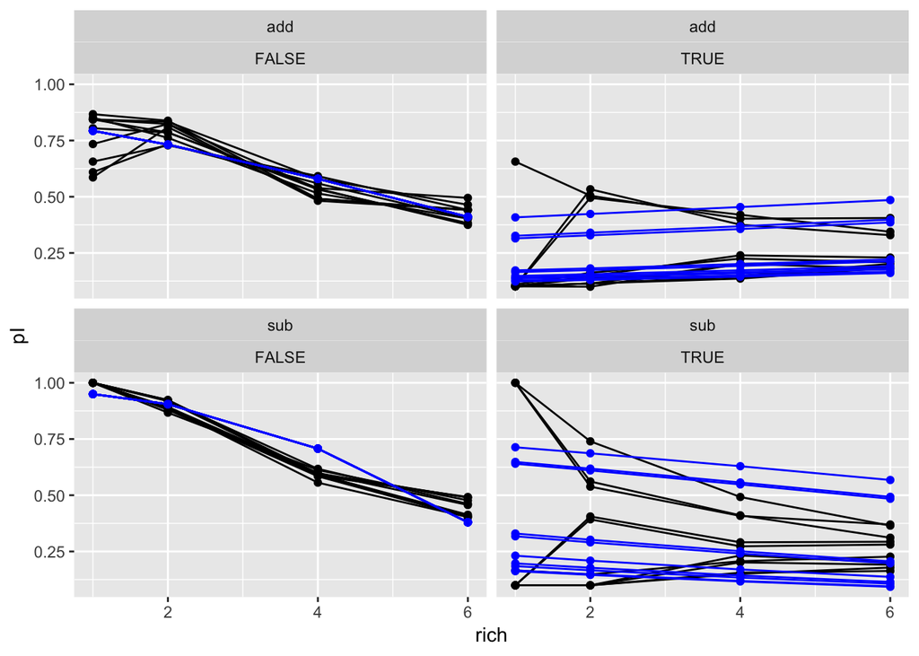

```r
#plot predicted. seems like slope should vary with blocks?
pred <- predict(model, type="response")
dat40$pred <- pred
ggplot(dat40, aes(rich, pI, group=rep2))+
  geom_point()+
  geom_line()+
  geom_point(aes(rich, pred), color='blue')+
  geom_line(aes(rich, pred), color='blue')+
  facet_wrap(~dens+rand)
```

I tried a similar thing for when I use total infections as the disease metric. I use a neg. binomial model and run into similar issues.

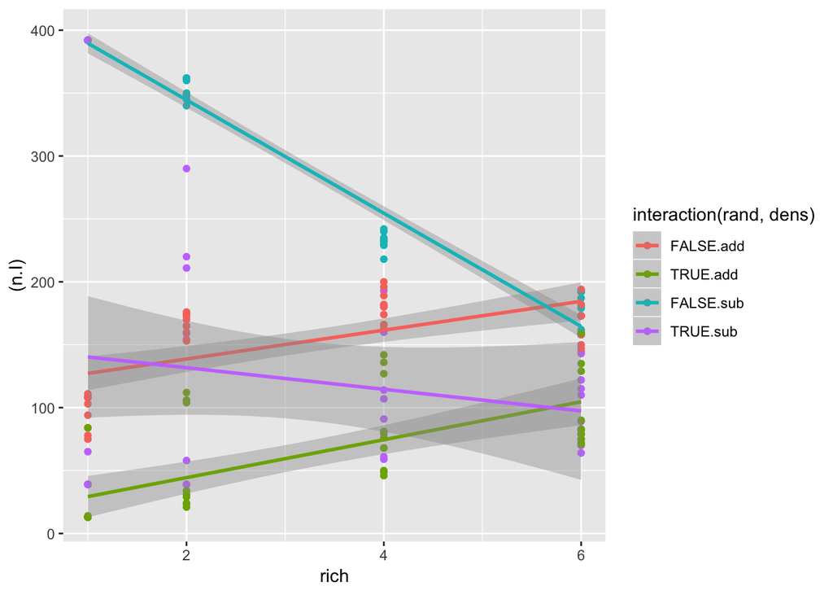

```r
ggplot(dat40, aes(rich, (n.I), color=interaction(rand, dens), group=interaction(rand, dens)))+
  geom_point()+
  geom_smooth(method='lm')#+
```

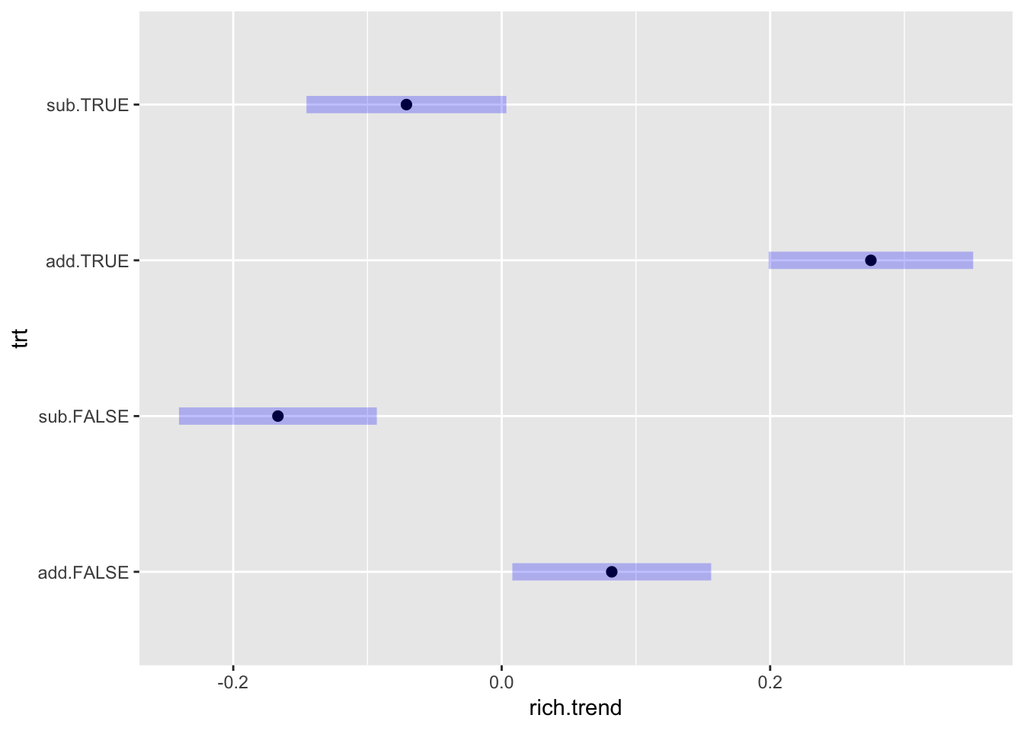

```r
  #facet_wrap(~dens+rand)

m3 <- MASS::glm.nb(n.I ~ trt*rich, data=dat40)
#summary(m3)

lst2 <- emmeans::lstrends(m3, "trt", var="rich")
plot(lst2)
```

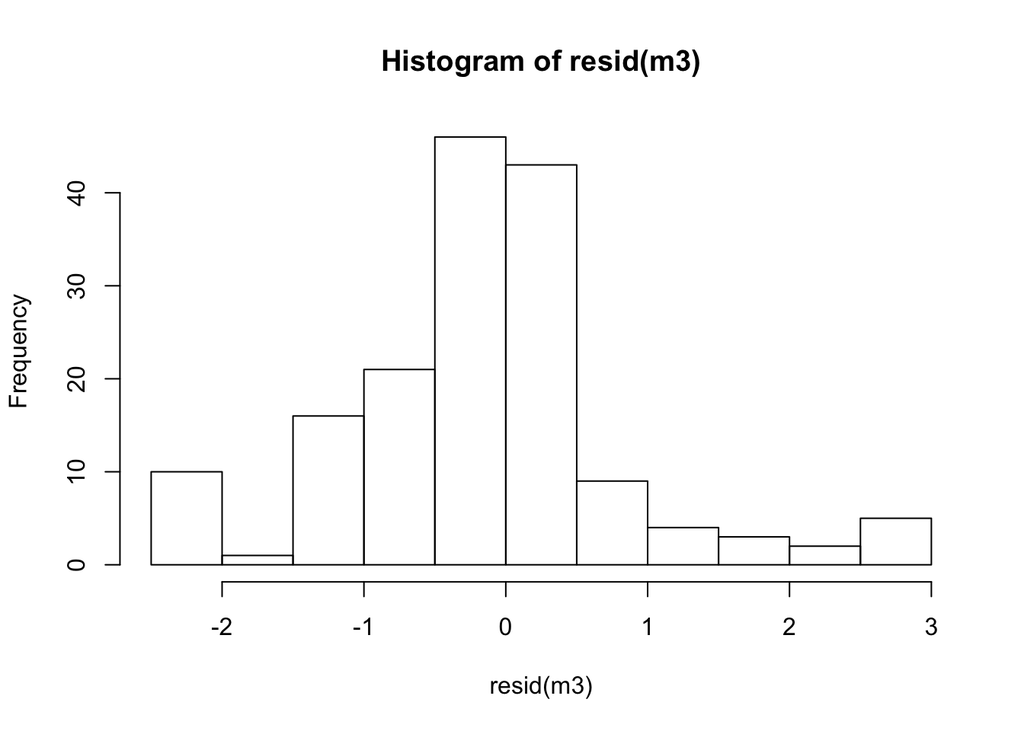

```r
#model eval
hist(resid(m3))#not normal
```

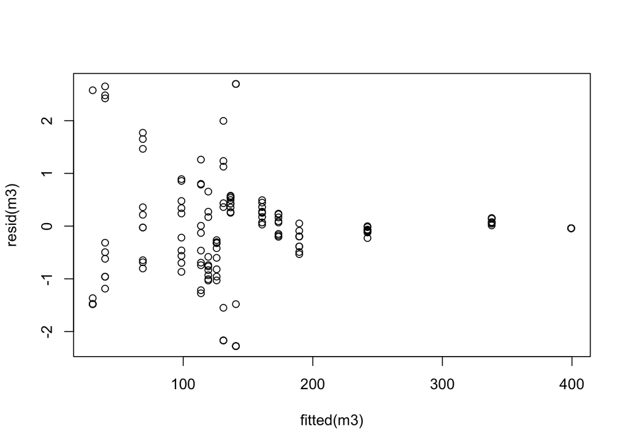

```r
#qqnorm(resid(m3))+qqline(resid(m3))
plot(resid(m3) ~ fitted(m3)) #ouch. heteroscedastic.
```